# Multivarible Analysis

Group 4: Aishe Memetova, Haotian Bu, Jon White, Vitalii Zakhozhyi

March 9, 2019

Using the Seattle Sound Transit Data of October-November 2015, we will try to explore factors which may affect people’s probability of using cash for the trip.

# Intro: Loading Data and Describing the Data

Loading neccessary packages, calling dataset and preparing it for analysis

```r
library(ggplot2)
library(scales)
mydata1=read.csv("https://raw.githubusercontent.com/karllovepolicy/Data_Visual_Final_Tutorial/master/FinalData.csv")
```

# Multi-variable plot

In this section, we will explore the realationship among the probability of using cash for this trip, whether people have vehicles, the purpose of this trip, and frequency of using public transportation.

First, we need to make our dataset ready for regression. Following code select dependent variables and explanatory variables, then set the right format for each variable.

```r
#change names of explanatory variables
library(dplyr)
mydata1 <- rename(mydata1,'number_of_trips'='oneway_all_clean', 'vehicle'='hhveh_clean')

# transform explanatory varibles from factor to numeric, add "-1" in command because Factors in R are represented internally as integers and the first factor is 1.
mydata1$vehicle <- as.numeric(mydata1$vehicle)-1
mydata1$number_of_trips <- as.numeric(mydata1$number_of_trips)-1

# subset, select needed variables:
mydata2 <- mydata1 %>% mutate(cashlove = ifelse(faretype=="Cash", 1, 0), vehicle = ifelse(vehicle>0, 1, 0)) %>% select(cashlove, purpose, number_of_trips, vehicle) %>% filter(purpose != "#NULL!")
# set the correct type for explanatory variables
mydata2$cashlove <- factor(mydata2$cashlove)
mydata2$vehicle <- factor(mydata2$vehicle)
mydata2$purpose <- factor(mydata2$purpose) #reset the level of variable "purpose"
mydata2$number_of_trips <- as.numeric(mydata2$number_of_trips)
head(mydata2,5)
```

```
##   cashlove                  purpose number_of_trips vehicle
## 1        0 Home Based Non-Work Trip              32       1
## 2        0     Home Based Work Trip               0       1
## 3        0 Home Based Non-Work Trip               0       1
## 4        0 Home Based Non-Work Trip               0       1
## 5        0     Home Based Work Trip               8       1
```

Here we use logit model since our dependent variable is a binary variable. Our reference group is people whose purpose of this trip is home-based non-work trip and don’t have vehicles in home.

```r
library(dotwhisker)
library(broom)
#just use purpose as explantary variable
mylogit1 <- glm(cashlove ~ purpose, data = mydata2, family = "binomial")
model1 = tidy(mylogit1) %>%   # we save the result as a tidy object and...
    mutate(model = "Model 1")
#use purpose and number of trips
mylogit2 <- glm(cashlove ~ purpose + number_of_trips, data = mydata2, family = "binomial")
model2 = tidy(mylogit2) %>%   # we save the result as a tidy object and...
    mutate(model = "Model 2")
#use all three explanatory varibales
mylogit3 <- glm(cashlove ~ purpose + number_of_trips + vehicle, data = mydata2, family = "binomial")
model3 = tidy(mylogit3) %>%   # we save the result as a tidy object and...
    mutate(model = "Model 3")

summary(mylogit3)
```

```
##
## Call:
## glm(formula = cashlove ~ purpose + number_of_trips + vehicle,
##     family = "binomial", data = mydata2)
##
## Deviance Residuals:
##     Min       1Q   Median       3Q      Max
## -0.6367  -0.5370  -0.2671  -0.2633   3.2170
##
## Coefficients:
##                              Estimate Std. Error z value Pr(>|z|)
## (Intercept)                 -1.892369   0.251305  -7.530 5.07e-14 ***
## purposeHome Based Work Trip -1.452141   0.180792  -8.032 9.58e-16 ***
## purposeNon-home based trip   0.370639   0.143066   2.591  0.00958 **
## number_of_trips             -0.035638   0.007562  -4.713 2.44e-06 ***
## vehicle1                     0.028863   0.244962   0.118  0.90620
## ---
## Signif. codes:  0 '***' 0.001 '**' 0.01 '*' 0.05 '.' 0.1 ' ' 1
##
## (Dispersion parameter for binomial family taken to be 1)
##
##     Null deviance: 1928.6  on 3311  degrees of freedom
## Residual deviance: 1753.7  on 3307  degrees of freedom
## AIC: 1763.7
##
## Number of Fisher Scoring iterations: 6
```

Comparison among three models:

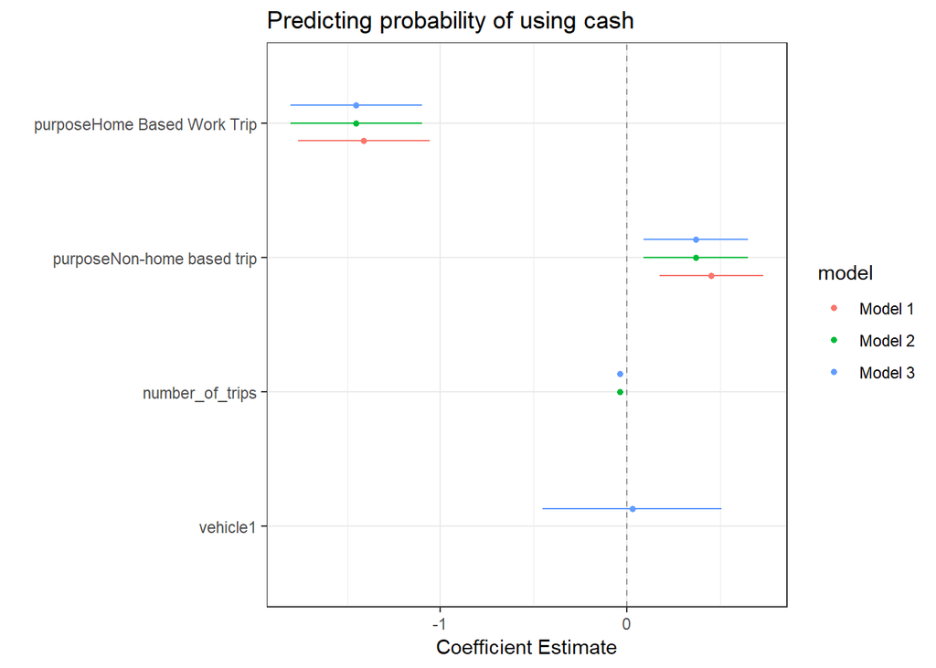

```r
allModels=rbind(model1, model2, model3)

dwplot(allModels, vline = geom_vline(xintercept = 0, colour = "grey60", linetype = 2)) +
  xlab("Coefficient Estimate") +
  ylab("") +
  ggtitle("Predicting probability of using cash") +
  theme_bw()
```

From plot above, we can see that compared with reference group, people whose purpose is home based work trip have less probability using cash, while people whose purpose is non-home based trip is more likely to use cash. The more trips people have in each month, the less likelihood people would use cash. However, the difference on cash usage between people who have vehicles in home and people who don’t is non-significant.